# Assignment 2_Q1

```python
import warnings
warnings.filterwarnings("ignore")
```

```python
import librosa
import librosa.display
from sklearn.preprocessing import minmax_scale
import IPython.display as ipd
import matplotlib.pyplot as plt
%matplotlib inline
import numpy as np
import pandas as pd
import os,random,shutil
```

```python
path = os.getcwd()+"\\Data"
dst=os.getcwd()+"\\Working"

def getRandomFile(path):
    randomDir = random.choice([(x) for x in list(os.scandir(path)) if x.is_dir()]).name
    randomFile = random.choice([f for f in list(os.scandir(path=path+"\\"+randomDir))]).name
    if os.path.isdir(path+"\\"+randomFile):
        print("Internal Directory")
        randomFile1 = random.choice([f for f in list(os.scandir(path=path+"\\"+randomDir+"\\"+randomFile))]).name
        print(randomFile1)
        return path+"\\"+randomDir+"\\"+randomFile+"\\"+randomFile1
    else:
        return path+"\\"+randomDir+"\\"+randomFile

for x in range(500):
    print(x)
    shutil.copy(getRandomFile(path),dst)
```

[output not shown]

[output cut: 477 more lines]

[output not shown]

```python
h=[os.getcwd()+"\\Working\\03-01-03-01-01-01-03.wav",os.getcwd()+"\\Working\\03-01-03-01-01-01-04.wav",os.getcwd()+"\\Working\\03-01-03-02-02-02-03.wav",os.getcwd()+"\\Working\\03-01-03-02-02-02-11.wav"]
```

```python
s=[os.getcwd()+"\\Working\\03-01-04-01-01-01-19.wav",os.getcwd()+"\\Working\\03-01-04-01-01-01-16.wav",os.getcwd()+"\\Working\\03-01-04-02-02-02-03.wav",os.getcwd()+"\\Working\\03-01-04-02-02-02-05.wav"]
```

```python
h[1]
```

```
'C:\\Users\\sanke\\Documents\\SpeechRecognition\\MTech-AI-SR-Sanketh_Iyer-R003\\Assignment 2\\Working\\03-01-03-01-01-01-04.wav'
```

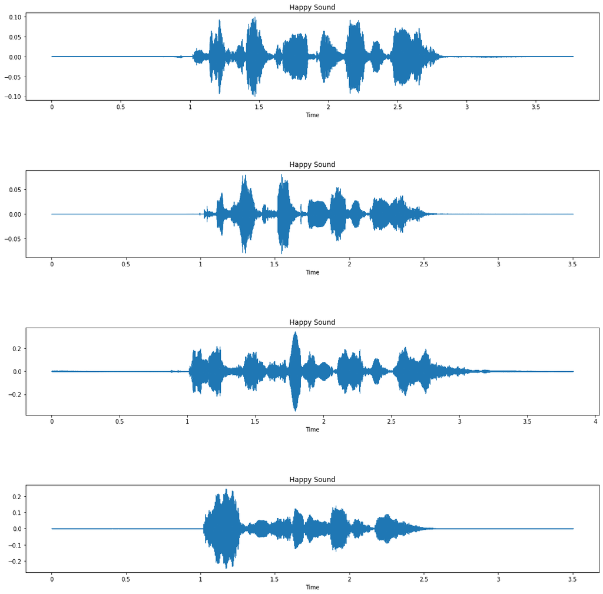

```python
figure,axis = plt.subplots(4,figsize=(18,18))
plt.subplots_adjust(hspace=0.8)
x , sr = librosa.load(h[0])
axis[0].title.set_text("Happy Sound")
librosa.display.waveshow(x, sr=sr,ax=axis[0])
x_ , sr_ = librosa.load(h[1])
axis[1].title.set_text("Happy Sound")
librosa.display.waveshow(x_, sr=sr_,ax=axis[1])
x1 , sr1 = librosa.load(h[2])
axis[2].title.set_text("Happy Sound")
librosa.display.waveshow(x1, sr=sr1,ax=axis[2])
x1_ , sr1_ = librosa.load(h[3])
axis[3].title.set_text("Happy Sound")
librosa.display.waveshow(x1_, sr=sr1_,ax=axis[3])
plt.show()
```

#### It shows many sharp peaks

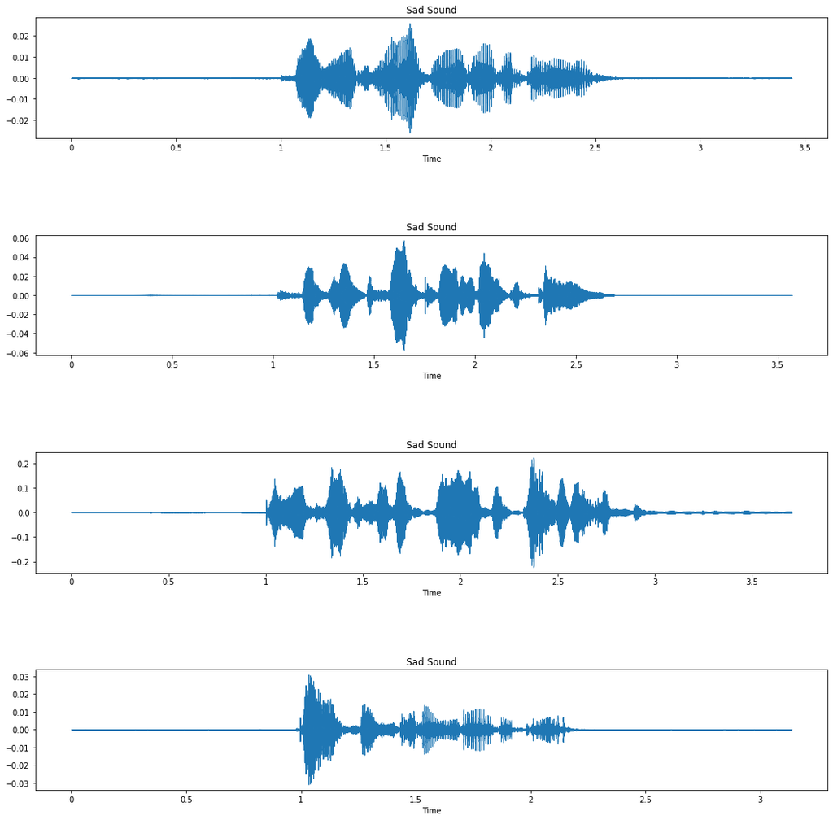

```python
figure,axis = plt.subplots(4,figsize=(18,18))
plt.subplots_adjust(hspace=0.8)
x , sr = librosa.load(s[0])
axis[0].title.set_text("Sad Sound")
librosa.display.waveshow(x, sr=sr,ax=axis[0])
x_ , sr_ = librosa.load(s[1])
axis[1].title.set_text("Sad Sound")
librosa.display.waveshow(x_, sr=sr_,ax=axis[1])
x1 , sr1 = librosa.load(s[2])
axis[2].title.set_text("Sad Sound")
librosa.display.waveshow(x1, sr=sr1,ax=axis[2])
x1_ , sr1_ = librosa.load(s[3])
axis[3].title.set_text("Sad Sound")
librosa.display.waveshow(x1_, sr=sr1_,ax=axis[3])
plt.show()
```

#### It shows lesser peaks compared to happy sounds and it shows a kind of spread indicative of low tone for sad statements

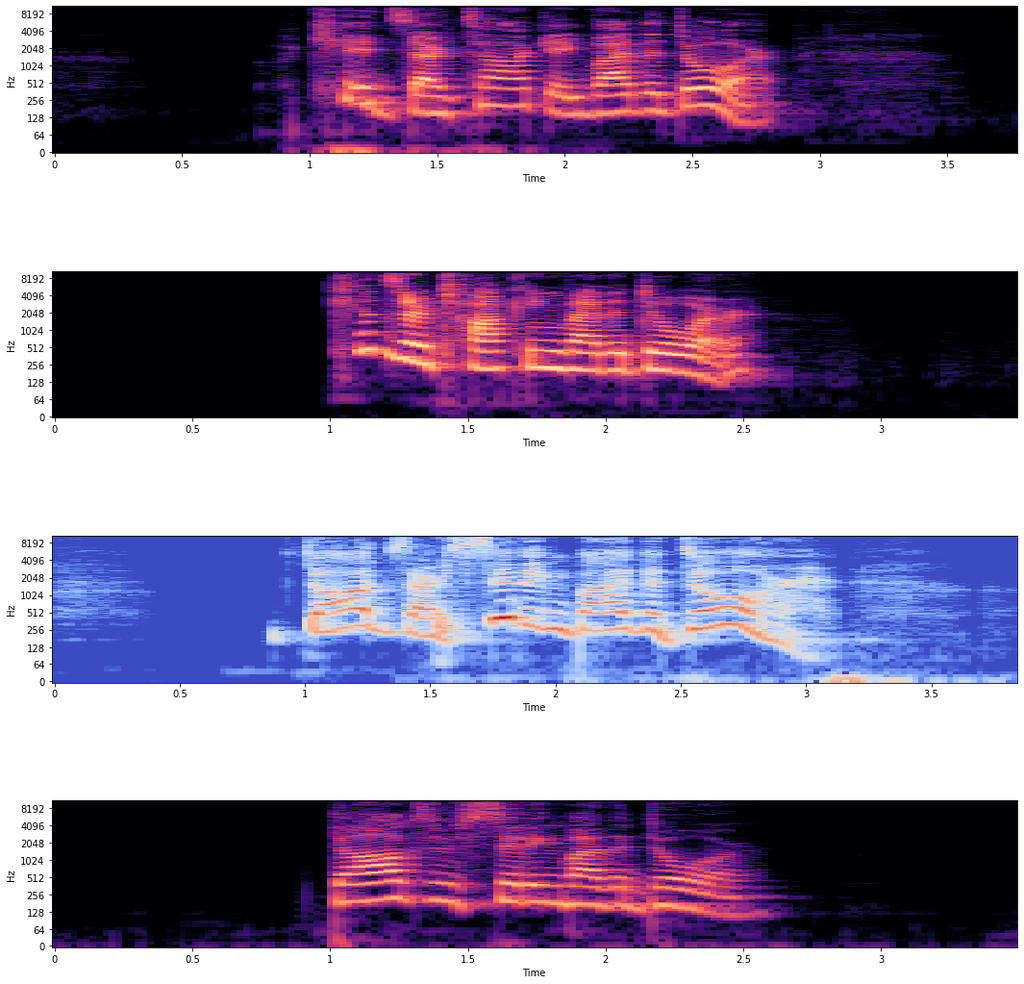

```python
figure,axis = plt.subplots(4,figsize=(18,18))
plt.subplots_adjust(hspace=0.8)
for i in range(4):
    x , sr = librosa.load(h[i])
    X = librosa.stft(x)

    Xdb = librosa.amplitude_to_db(abs(X))
    librosa.display.specshow(Xdb, sr=sr, x_axis='time', y_axis='log',ax=axis[i])
plt.show()
```

### The frequencies are farily dispersed for happy audio

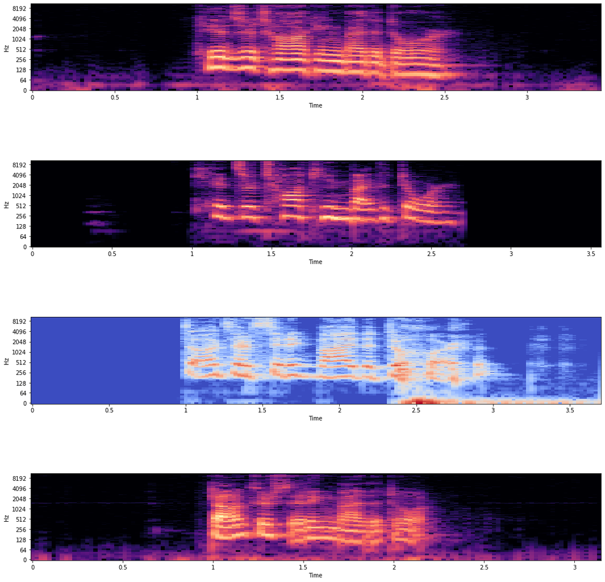

```python
figure,axis = plt.subplots(4,figsize=(18,18))
plt.subplots_adjust(hspace=0.8)
for i in range(4):
    x , sr = librosa.load(s[i])
    X = librosa.stft(x)

    Xdb = librosa.amplitude_to_db(abs(X))
    librosa.display.specshow(Xdb, sr=sr, x_axis='time', y_axis='log',ax=axis[i])
plt.show()
```

### Waveform shows amplitude over time, but we can’t really see what’s happening at individual frequencies.Sad frequencies show less dispersion.

```
Sum of zero crossing  19321
Sum of zero crossing  17013
Sum of zero crossing  13771
Sum of zero crossing  14277
```

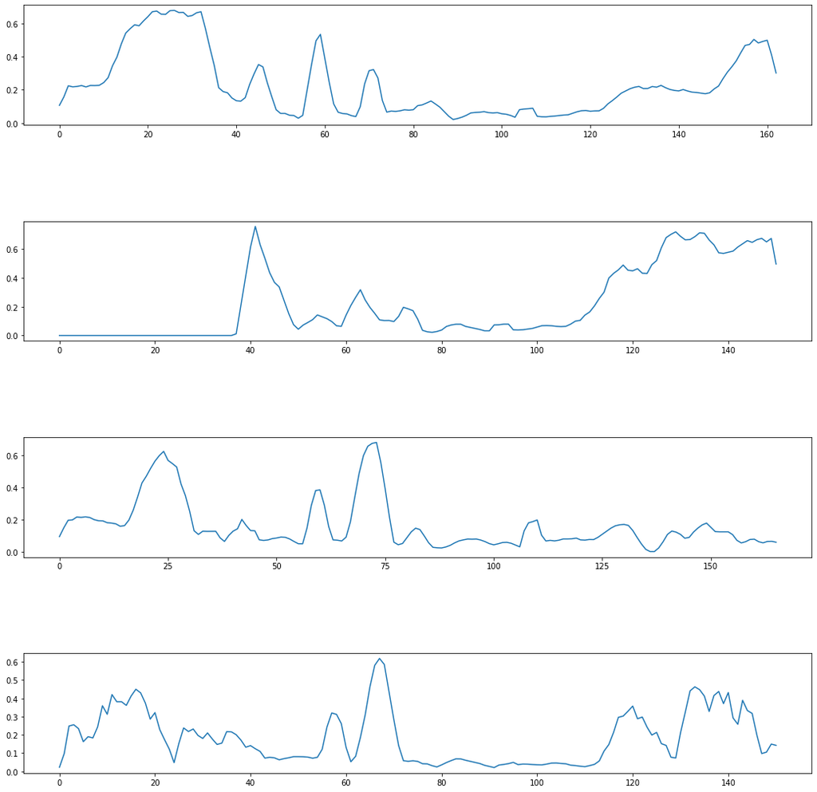

```python
figure,axis = plt.subplots(4,figsize=(18,18))
plt.subplots_adjust(hspace=0.8)

for i in range(4):
    x , sr = librosa.load(h[i])
    zero_crossings = librosa.zero_crossings(x)
    print("Sum of zero crossing ", zero_crossings.sum())
    zcrs = librosa.feature.zero_crossing_rate(x)
    axis[i].plot(zcrs[0])
plt.show()
```

#### The zero-crossing rate (ZCR) is the rate at which a signal changes from positive to zero to negative or from negative to zero to positive.The signals are less smooth for happy sounds

```
Sum of zero crossing  14693
Sum of zero crossing  24923
Sum of zero crossing  9061
Sum of zero crossing  18477
```

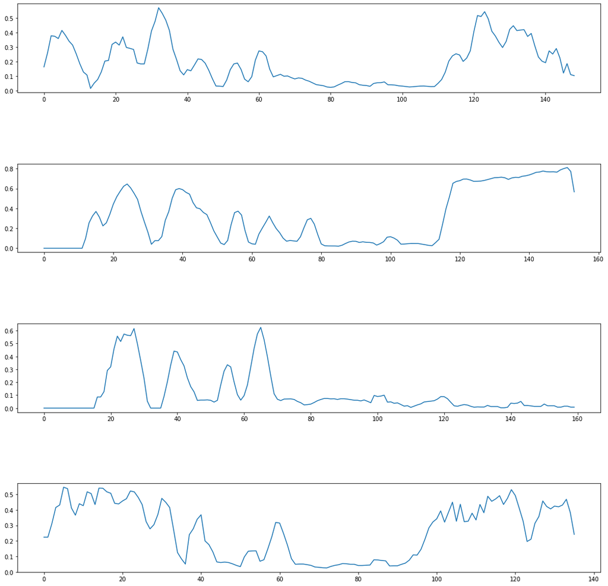

```python
figure,axis = plt.subplots(4,figsize=(18,18))
plt.subplots_adjust(hspace=0.8)

for i in range(4):
    x , sr = librosa.load(s[i])
    zero_crossings = librosa.zero_crossings(x)
    print("Sum of zero crossing ", zero_crossings.sum())
    zcrs = librosa.feature.zero_crossing_rate(x)
    axis[i].plot(zcrs[0])
plt.show()
```

```python
from sklearn.preprocessing import minmax_scale
def normalize(x, axis=0):
    return minmax_scale(x, axis=axis)
```

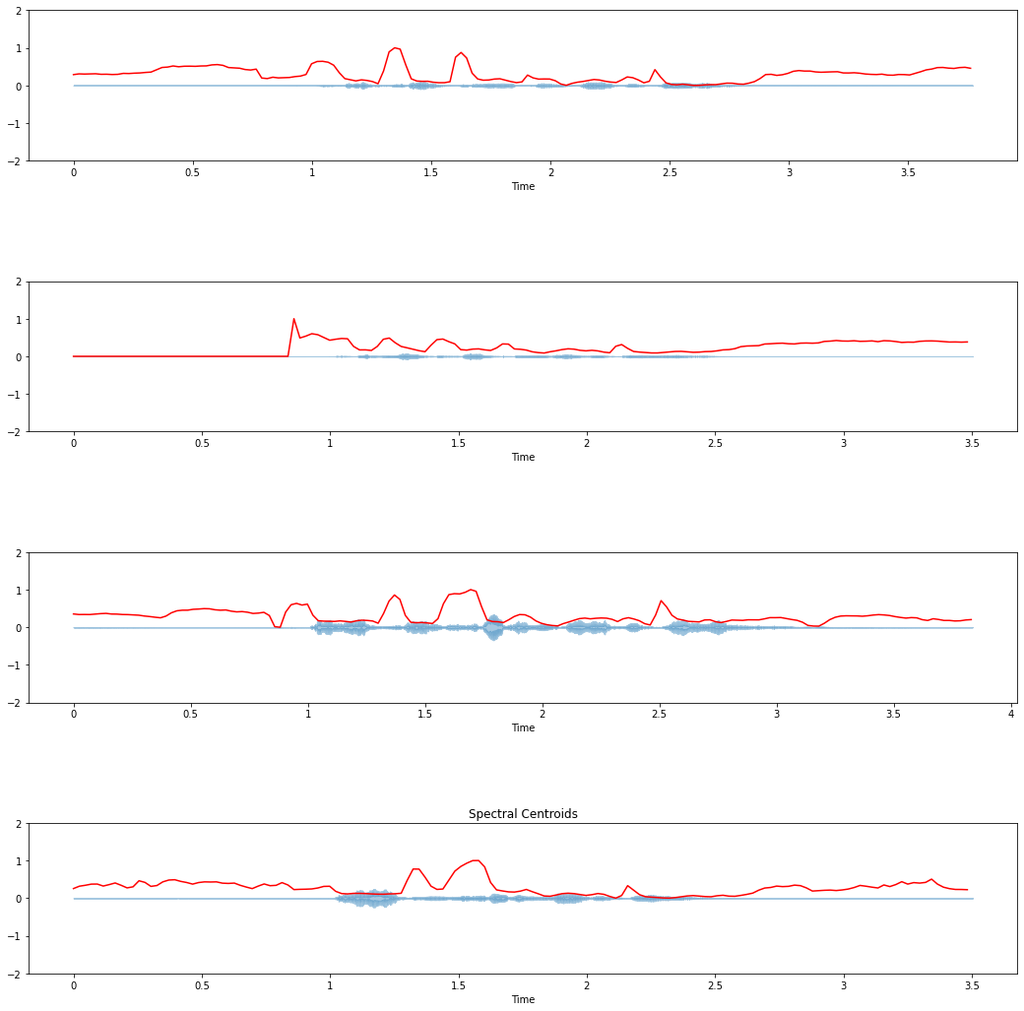

```python
figure,axis = plt.subplots(4,figsize=(18,18))
plt.subplots_adjust(hspace=0.8)
plt.setp(axis, ylim=(-2,2))
plt.title('Spectral Centroids')
for i in range(4):
    x , sr = librosa.load(h[i])
    spectral_centroids = librosa.feature.spectral_centroid(x, sr=sr)[0]
    frames = range(len(spectral_centroids))
    t = librosa.frames_to_time(frames)
    librosa.display.waveshow(x, sr=sr, alpha=0.4,ax=axis[i])
    axis[i].plot(t, normalize(spectral_centroids), color='r')
plt.show()
```

#### Spectral centroid is a good predictor of the "brightness" of a sound. Happy sound signals seems more prevalent

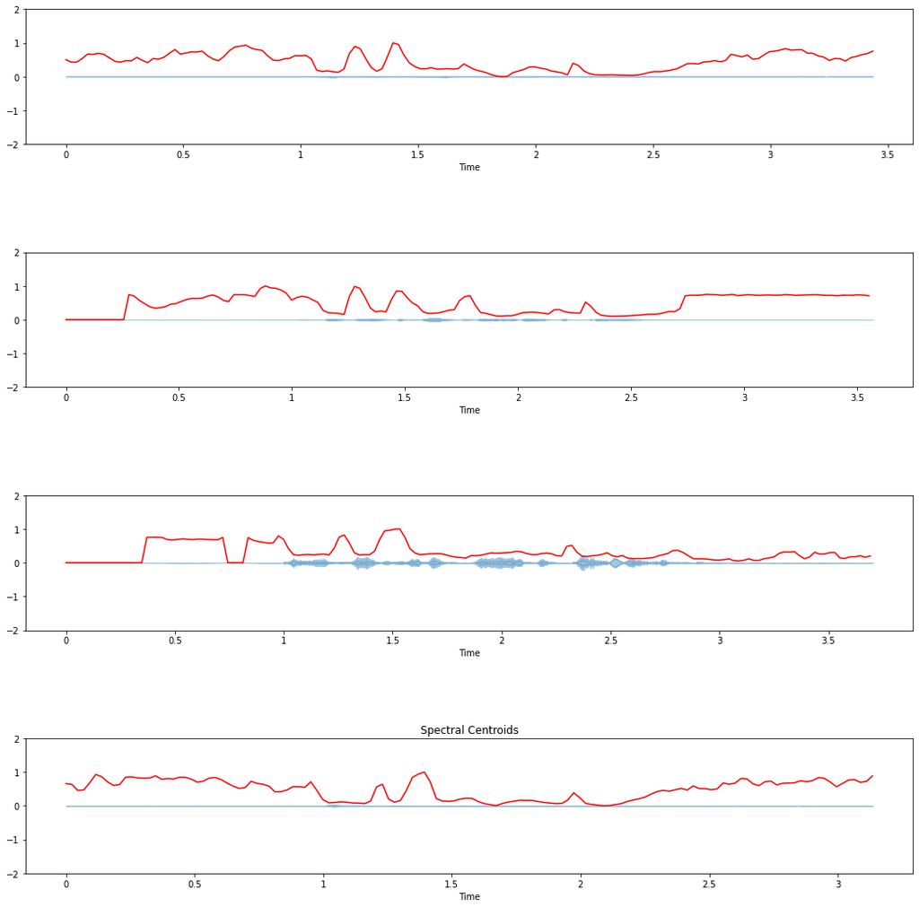

```python
figure,axis = plt.subplots(4,figsize=(18,18))
plt.subplots_adjust(hspace=0.8)
plt.setp(axis, ylim=(-2,2))
plt.title('Spectral Centroids')
for i in range(4):
    x , sr = librosa.load(s[i])
    spectral_centroids = librosa.feature.spectral_centroid(x, sr=sr)[0]
    frames = range(len(spectral_centroids))
    t = librosa.frames_to_time(frames)
    librosa.display.waveshow(x, sr=sr, alpha=0.4,ax=axis[i])
    axis[i].plot(t, normalize(spectral_centroids), color='r')
plt.show()
```

#### Sads sounds are less brighter due to low tones in which they are spoken

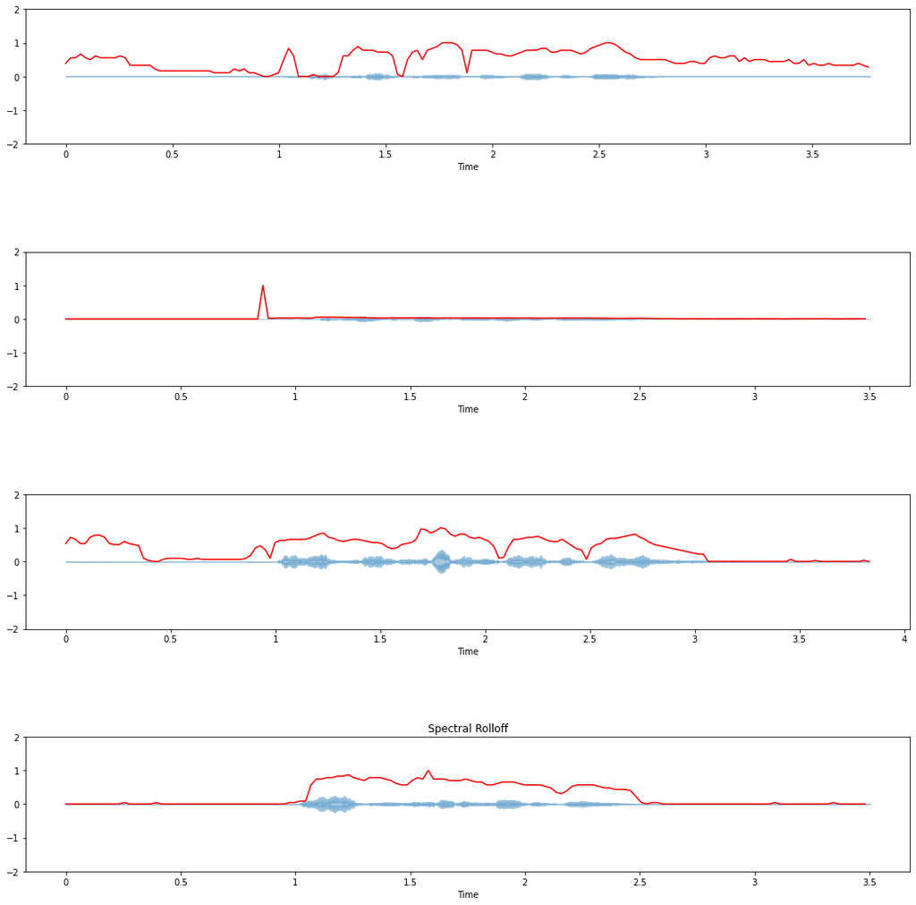

```python
figure,axis = plt.subplots(4,figsize=(18,18))
plt.subplots_adjust(hspace=0.8)
plt.setp(axis, ylim=(-2,2))
plt.title('Spectral Rolloff')
for i in range(4):
    x , sr = librosa.load(h[i])
    spectral_rolloff = librosa.feature.spectral_rolloff(x, sr=sr, roll_percent=0.01)[0]
    frames = range(len(spectral_rolloff))
    t = librosa.frames_to_time(frames)
    librosa.display.waveshow(x, sr=sr, alpha=0.4,ax=axis[i])
    axis[i].plot(t, normalize(spectral_rolloff), color='r')
plt.show()
```

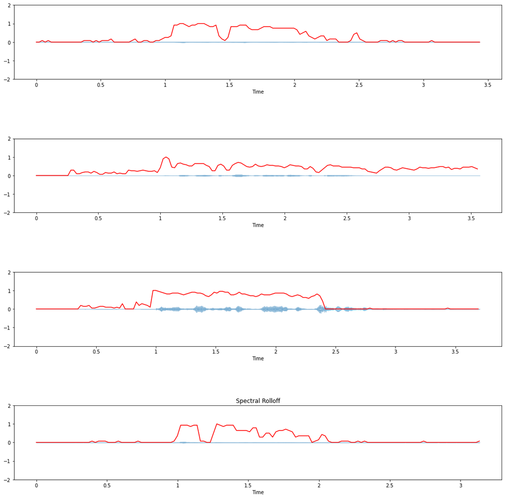

```python
figure,axis = plt.subplots(4,figsize=(18,18))
plt.subplots_adjust(hspace=0.8)
plt.setp(axis, ylim=(-2,2))
plt.title('Spectral Rolloff')
for i in range(4):
    x , sr = librosa.load(s[i])
    spectral_rolloff = librosa.feature.spectral_rolloff(x, sr=sr, roll_percent=0.01)[0]
    frames = range(len(spectral_rolloff))
    t = librosa.frames_to_time(frames)
    librosa.display.waveshow(x, sr=sr, alpha=0.4,ax=axis[i])
    axis[i].plot(t, normalize(spectral_rolloff), color='r')
plt.show()
```

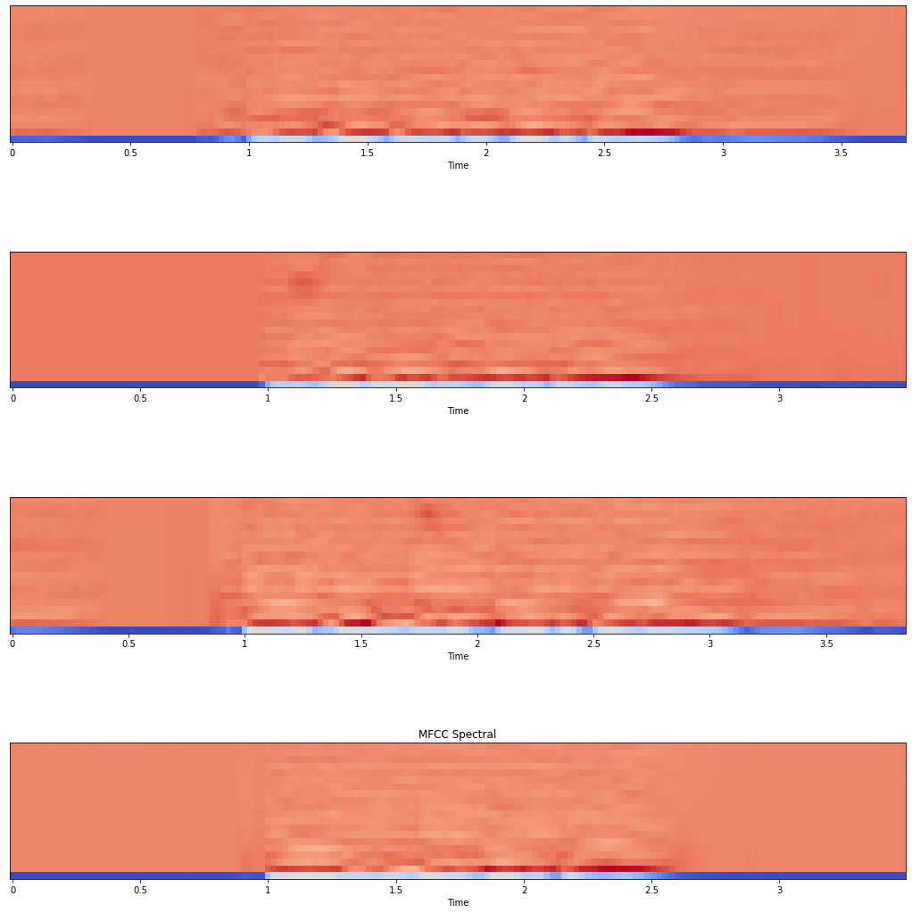

```python
figure,axis = plt.subplots(4,figsize=(18,18))
plt.subplots_adjust(hspace=0.8)
plt.title('MFCC Spectral')
for i in range(4):
    x , sr = librosa.load(h[i])
    mfccs = librosa.feature.mfcc(y=x, sr=sr)
    librosa.display.specshow(mfccs, sr=sr, x_axis='time',ax=axis[i])
plt.show()
```

#### Mel scale is the scale of pitches that can be felt by the listener to be equal in distance from one another. We see more changes in colors wrt pitches in happy sound.

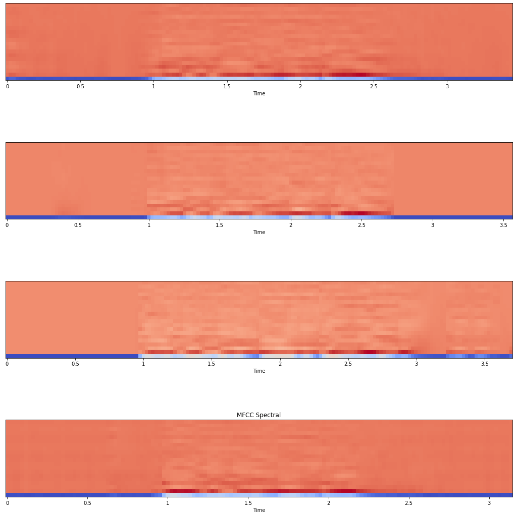

```python
figure,axis = plt.subplots(4,figsize=(18,18))
plt.subplots_adjust(hspace=0.8)
plt.title('MFCC Spectral')
for i in range(4):
    x , sr = librosa.load(s[i])
    mfccs = librosa.feature.mfcc(y=x, sr=sr)
    librosa.display.specshow(mfccs, sr=sr, x_axis='time',ax=axis[i])
plt.show()
```

#### We see less changes in colors wrt pitches in sad sound.